# Biostat776project2

Wendy Espinoza Camejo

2023-09-25

```r
library(tidyverse)
library(tidytuesdayR)
```

### Part 1: Fun with functions

```r
Exp <- function(x, k){
  k <- 1:k
  sum(x^k/(factorial(k)))
}
Exp(2,5)
```

```
## [1] 6.266667
```

1B. Sample mean and sample standard deviation Next, write two functions called sample_mean() and sample_sd() that takes as input a vector of data of length and calculates the sample average and sample standard deviation for the set of observations.

```r
sample_mean <- function(x) {
  N <- length(x)
  sum(x, na.rm = TRUE)/N
}

sample_sd <- function(x) {
  N <- length(x)
  sqrt(sum((x - sample_mean(x))^2)/(N-1))
}
sample_mean(2:100)
```

```
## [1] 51
```

```r
sample_sd(2:100)
```

```
## [1] 28.72281
```

1C. Confidence intervals

```r
calculate_CI <- function(x, conf) {
    N <-length(x)
    alpha <- 1 - conf
  degrees_freedom <- N - 1
  #t_score <- qt(p = alpha / 2, df = degrees_freedom, lower.tail = FALSE)
  lower_bound <- sample_mean(x)- 1.95*sample_sd(x)
  upper_bound <- sample_mean(x)+ 1.95*sample_sd(x)
  bound <- c(lower_bound, upper_bound)
  #print(t_score)
  print(bound)
}

 calculate_CI(1:100, conf = 0.95)
```

```
## [1]  -6.072409 107.072409
```

### Part 2: Wrangling data

```r
library("here")
library("tidyverse")
library("dplyr")

if(!dir.exists(here("data"))){
  dir.create(here("data"))
}
if (!file.exists(here("data", "tuesdata_rainfall.RDS"))) {
    rainfall_csv <- 'https://raw.githubusercontent.com/rfordatascience/tidytuesday/master/data/2020/2020-01-07/rainfall.csv'
    temperature_csv <- 'https://raw.githubusercontent.com/rfordatascience/tidytuesday/master/data/2020/2020-01-07/temperature.csv'
    rainfall <- readr:: read_csv(rainfall_csv)
    temperature <- readr::read_csv(temperature_csv)
  # save the files to RDS objects
    saveRDS(rainfall, file = here("data", "tuesdata_rainfall.RDS"))
    saveRDS(temperature, file = here("data", "tuesdata_temperature.RDS"))
}
```

```r
rainfall <- readRDS(here("data", "tuesdata_rainfall.RDS"))
temperature <- readRDS(here("data", "tuesdata_temperature.RDS"))
```

```r
library(tidyverse)
glimpse(rainfall)
```

```
## Rows: 179,273
## Columns: 11
## $ station_code <chr> "009151", "009151", "009151", "009151", "009151", "009151…
## $ city_name    <chr> "Perth", "Perth", "Perth", "Perth", "Perth", "Perth", "Pe…
## $ year         <dbl> 1967, 1967, 1967, 1967, 1967, 1967, 1967, 1967, 1967, 196…
## $ month        <chr> "01", "01", "01", "01", "01", "01", "01", "01", "01", "01…
## $ day          <chr> "01", "02", "03", "04", "05", "06", "07", "08", "09", "10…
## $ rainfall     <dbl> NA, NA, NA, NA, NA, NA, NA, NA, NA, NA, NA, NA, NA, NA, N…
## $ period       <dbl> NA, NA, NA, NA, NA, NA, NA, NA, NA, NA, NA, NA, NA, NA, N…
## $ quality      <chr> NA, NA, NA, NA, NA, NA, NA, NA, NA, NA, NA, NA, NA, NA, N…
## $ lat          <dbl> -31.96, -31.96, -31.96, -31.96, -31.96, -31.96, -31.96, -…
## $ long         <dbl> 115.79, 115.79, 115.79, 115.79, 115.79, 115.79, 115.79, 1…
## $ station_name <chr> "Subiaco Wastewater Treatment Plant", "Subiaco Wastewater…
```

```r
glimpse(temperature)
```

```
## Rows: 528,278
## Columns: 5
## $ city_name   <chr> "PERTH", "PERTH", "PERTH", "PERTH", "PERTH", "PERTH", "PER…
## $ date        <date> 1910-01-01, 1910-01-02, 1910-01-03, 1910-01-04, 1910-01-0…
## $ temperature <dbl> 26.7, 27.0, 27.5, 24.0, 24.8, 24.4, 25.3, 28.0, 32.6, 35.9…
## $ temp_type   <chr> "max", "max", "max", "max", "max", "max", "max", "max", "m…
## $ site_name   <chr> "PERTH AIRPORT", "PERTH AIRPORT", "PERTH AIRPORT", "PERTH …
```

Using the rainfall and temperature data, perform the following steps and create a new data frame called df: 1. Start with rainfall dataset and drop any rows with NAs. 2. Create a new column titled date that combines the columns year, month, day into one column separated by “-”. (e.g. “2020-01-01”). This column should not be a character, but should be recognized as a date. (Hint: check out the ymd() function in lubridate R package). You will also want to add a column that just keeps the year. 3. Using the city_name column, convert the city names (character strings) to all upper case. 4. Join this wrangled rainfall dataset with the temperature dataset such that it includes only observations that are in both data frames. (Hint: there are two keys that you will need to join the two datasets together). (Hint: If all has gone well thus far, you should have a dataset with 83,964 rows and 13 columns).

```r
library("lubridate")
rainfall_na <- drop_na(rainfall)
## I can also use na.omit()
glimpse(rainfall_na)
```

```
## Rows: 64,476
## Columns: 11
## $ station_code <chr> "009151", "009151", "009151", "009151", "009151", "009151…
## $ city_name    <chr> "Perth", "Perth", "Perth", "Perth", "Perth", "Perth", "Pe…
## $ year         <dbl> 1967, 1967, 1967, 1967, 1967, 1967, 1967, 1967, 1967, 196…
## $ month        <chr> "07", "07", "07", "07", "07", "07", "07", "07", "07", "07…
## $ day          <chr> "05", "06", "07", "10", "11", "14", "15", "16", "17", "18…
## $ rainfall     <dbl> 2.8, 4.8, 5.8, 16.0, 1.0, 1.0, 15.5, 8.6, 12.2, 6.1, 11.7…
## $ period       <dbl> 1, 1, 1, 1, 1, 1, 1, 1, 1, 1, 1, 1, 1, 1, 1, 1, 1, 1, 1, …
## $ quality      <chr> "Y", "Y", "Y", "Y", "Y", "Y", "Y", "Y", "Y", "Y", "Y", "Y…
## $ lat          <dbl> -31.96, -31.96, -31.96, -31.96, -31.96, -31.96, -31.96, -…
## $ long         <dbl> 115.79, 115.79, 115.79, 115.79, 115.79, 115.79, 115.79, 1…
## $ station_name <chr> "Subiaco Wastewater Treatment Plant", "Subiaco Wastewater…
```

```r
rainfall_na_year <- cbind(rainfall_na, year_dup = rainfall_na$year)
rainfall_na_year_date <- rainfall_na_year %>%
 mutate(date = make_date(year, month, day))
class(rainfall_na_year_date$date)
```

```
## [1] "Date"
```

```r
glimpse(rainfall_na_year_date)
```

```
## Rows: 64,476
## Columns: 13
## $ station_code <chr> "009151", "009151", "009151", "009151", "009151", "009151…
## $ city_name    <chr> "Perth", "Perth", "Perth", "Perth", "Perth", "Perth", "Pe…
## $ year         <dbl> 1967, 1967, 1967, 1967, 1967, 1967, 1967, 1967, 1967, 196…
## $ month        <chr> "07", "07", "07", "07", "07", "07", "07", "07", "07", "07…
## $ day          <chr> "05", "06", "07", "10", "11", "14", "15", "16", "17", "18…
## $ rainfall     <dbl> 2.8, 4.8, 5.8, 16.0, 1.0, 1.0, 15.5, 8.6, 12.2, 6.1, 11.7…
## $ period       <dbl> 1, 1, 1, 1, 1, 1, 1, 1, 1, 1, 1, 1, 1, 1, 1, 1, 1, 1, 1, …
## $ quality      <chr> "Y", "Y", "Y", "Y", "Y", "Y", "Y", "Y", "Y", "Y", "Y", "Y…
## $ lat          <dbl> -31.96, -31.96, -31.96, -31.96, -31.96, -31.96, -31.96, -…
## $ long         <dbl> 115.79, 115.79, 115.79, 115.79, 115.79, 115.79, 115.79, 1…
## $ station_name <chr> "Subiaco Wastewater Treatment Plant", "Subiaco Wastewater…
## $ year_dup     <dbl> 1967, 1967, 1967, 1967, 1967, 1967, 1967, 1967, 1967, 196…
## $ date         <date> 1967-07-05, 1967-07-06, 1967-07-07, 1967-07-10, 1967-07-…
```

```r
rainfall_na_year_date <- rainfall_na_year_date %>%
  select(station_code, city_name, rainfall, period, quality, lat, long, station_name, year_dup, date)
glimpse(rainfall_na_year_date)
```

```
## Rows: 64,476
## Columns: 10
## $ station_code <chr> "009151", "009151", "009151", "009151", "009151", "009151…
## $ city_name    <chr> "Perth", "Perth", "Perth", "Perth", "Perth", "Perth", "Pe…
## $ rainfall     <dbl> 2.8, 4.8, 5.8, 16.0, 1.0, 1.0, 15.5, 8.6, 12.2, 6.1, 11.7…
## $ period       <dbl> 1, 1, 1, 1, 1, 1, 1, 1, 1, 1, 1, 1, 1, 1, 1, 1, 1, 1, 1, …
## $ quality      <chr> "Y", "Y", "Y", "Y", "Y", "Y", "Y", "Y", "Y", "Y", "Y", "Y…
## $ lat          <dbl> -31.96, -31.96, -31.96, -31.96, -31.96, -31.96, -31.96, -…
## $ long         <dbl> 115.79, 115.79, 115.79, 115.79, 115.79, 115.79, 115.79, 1…
## $ station_name <chr> "Subiaco Wastewater Treatment Plant", "Subiaco Wastewater…
## $ year_dup     <dbl> 1967, 1967, 1967, 1967, 1967, 1967, 1967, 1967, 1967, 196…
## $ date         <date> 1967-07-05, 1967-07-06, 1967-07-07, 1967-07-10, 1967-07-…
```

```r
class(rainfall_na_year_date$city_name)
```

```
## [1] "character"
```

```r
rainfall_na_year_date <- mutate( rainfall_na_year_date, city_name = toupper(city_name))
glimpse(temperature)
```

```
## Rows: 528,278
## Columns: 5
## $ city_name   <chr> "PERTH", "PERTH", "PERTH", "PERTH", "PERTH", "PERTH", "PER…
## $ date        <date> 1910-01-01, 1910-01-02, 1910-01-03, 1910-01-04, 1910-01-0…
## $ temperature <dbl> 26.7, 27.0, 27.5, 24.0, 24.8, 24.4, 25.3, 28.0, 32.6, 35.9…
## $ temp_type   <chr> "max", "max", "max", "max", "max", "max", "max", "max", "m…
## $ site_name   <chr> "PERTH AIRPORT", "PERTH AIRPORT", "PERTH AIRPORT", "PERTH …
```

```r
comb_df <- inner_join(rainfall_na_year_date,temperature, by = c('city_name', 'date'))
glimpse(comb_df)
```

```
## Rows: 83,964
## Columns: 13
## $ station_code <chr> "009151", "009151", "009151", "009151", "009151", "009151…
## $ city_name    <chr> "PERTH", "PERTH", "PERTH", "PERTH", "PERTH", "PERTH", "PE…
## $ rainfall     <dbl> 2.8, 2.8, 4.8, 4.8, 5.8, 5.8, 16.0, 16.0, 1.0, 1.0, 1.0, …
## $ period       <dbl> 1, 1, 1, 1, 1, 1, 1, 1, 1, 1, 1, 1, 1, 1, 1, 1, 1, 1, 1, …
## $ quality      <chr> "Y", "Y", "Y", "Y", "Y", "Y", "Y", "Y", "Y", "Y", "Y", "Y…
## $ lat          <dbl> -31.96, -31.96, -31.96, -31.96, -31.96, -31.96, -31.96, -…
## $ long         <dbl> 115.79, 115.79, 115.79, 115.79, 115.79, 115.79, 115.79, 1…
## $ station_name <chr> "Subiaco Wastewater Treatment Plant", "Subiaco Wastewater…
## $ year_dup     <dbl> 1967, 1967, 1967, 1967, 1967, 1967, 1967, 1967, 1967, 196…
## $ date         <date> 1967-07-05, 1967-07-05, 1967-07-06, 1967-07-06, 1967-07-…
## $ temperature  <dbl> 17.8, 8.7, 18.4, 8.0, 17.2, 10.5, 16.1, 4.4, 16.8, 4.1, 2…
## $ temp_type    <chr> "max", "min", "max", "min", "max", "min", "max", "min", "…
## $ site_name    <chr> "PERTH AIRPORT", "PERTH AIRPORT", "PERTH AIRPORT", "PERTH…
```

### Part 3: Data visualization

3A. Plotting temperature data over time

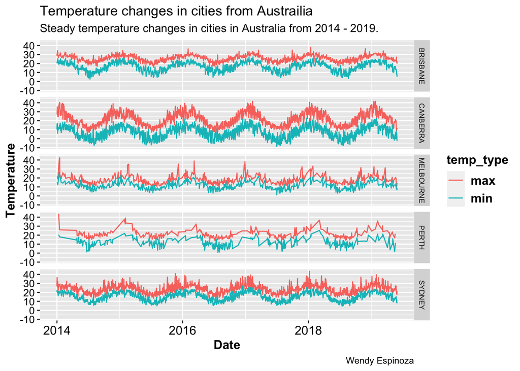

```r
library("ggplot2")
comb_df_plot <- filter(comb_df, year_dup >=2014)
comb_df_plot %>%
    ggplot(aes(
        x = date,
        y = temperature,
        fill = temp_type)) + geom_line(aes(color=temp_type)) + facet_grid(city_name ~.) + labs(title = "Temperature changes in cities from Austrailia",subtitle = "Steady temperature changes in cities in Australia from 2014 - 2019.", x= "Date", y="Temperature", caption = "Wendy Espinoza") + theme(axis.title.y = element_text(size = 12, face = "bold"),axis.title.x = element_text(size = 12, face = "bold"), legend.title = element_text(size = 12, face = "bold"),
        legend.text = element_text(size = 12, face = "bold", colour = "black"),
        axis.text.y = element_text(colour = "black", size = 10),axis.text.x = element_text(colour = "black", size = 12), strip.text.y = element_text(size = 7))
```

3B. Plotting rainfall over time

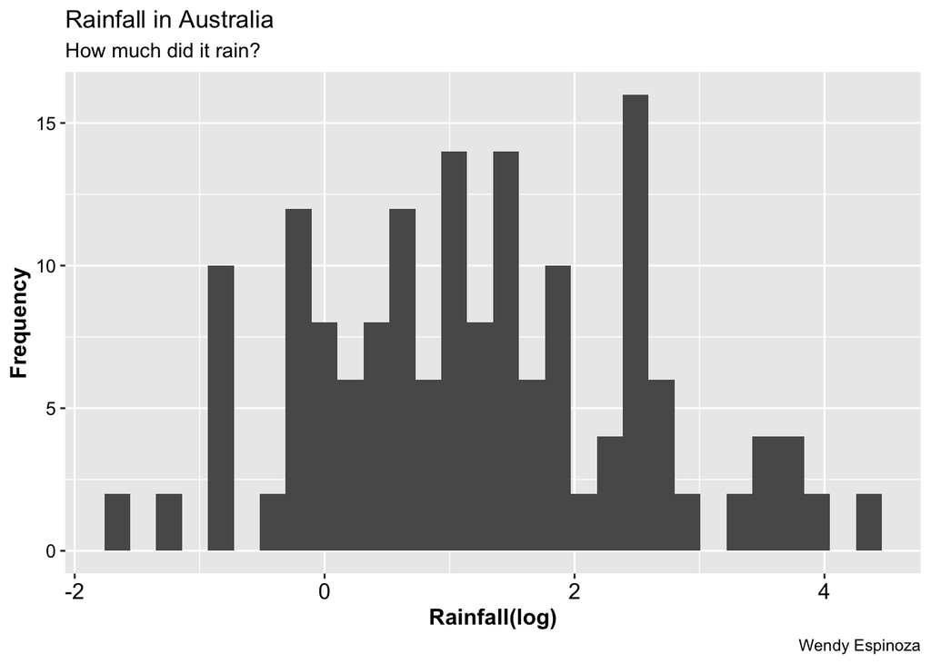

```r
 # comb_df %>%
 #     filter(city_name == "PERTH", year == 2000) %>%
 #     ggplot(aes(log(rainfall))) +
 #     geom_histogram()
comb_df_hist <- function(chosen_city = comb_df$city_name, chosen_year = comb_df$year_dup){
  if(!is.null(comb_df$city_name) && !is.null(comb_df$year_dup)){
  comb_df %>%
    filter(year_dup == chosen_year, city_name == chosen_city) %>%
  ggplot(aes(log(rainfall))) +
    geom_histogram() + labs(title = "Rainfall in Australia", subtitle = "How much did it rain?", x= "Rainfall(log)", y="Frequency", caption = "Wendy Espinoza") + theme(axis.title.y = element_text(size = 12, face = "bold"), axis.title.x = element_text(size = 12, face = "bold"), axis.text.y = element_text(colour = "black", size = 10),axis.text.x = element_text(colour = "black", size = 12), strip.text.y = element_text(size = 7))} else {
    stop("No measurement found in the year and city name selected", call. = FALSE)
}}
comb_df_hist("PERTH",  "2014")
```

[figure not shown]

```r
comb_df_hist("PERTH", "2022")
```

```r
comb_df_4 <- filter(comb_df, year_dup >= 2014)
rain_df <- comb_df_4 %>%
  group_by(city_name, year_dup) %>%
  summarise(
    Mean = sample_mean(rainfall), SD = sample_sd(rainfall), lower_bound = calculate_CI(rainfall,0.95) [1], upper_bound = calculate_CI(rainfall, 0.95) [2]
  )
```

```
## [1] -20.09665  27.78394
## [1] -38.17888  50.52807
## [1] -14.69149  18.87661
## [1] -17.10257  22.54078
## [1] -16.30285  21.24078
## [1] -10.28164  14.47631
## [1] -7.862251 11.003688
## [1] -8.547285 11.569999
## [1] -10.08852  14.39562
## [1] -6.692037  9.369723
## [1] -8.629535 11.222942
## [1] -8.845572 11.976698
## [1] -6.388446 14.055646
## [1] -7.08769 15.21382
## [1] -6.124804 14.773211
```

[output cut: 45 more lines]

```r
glimpse(rain_df)
```

```
## Rows: 30
## Columns: 6
## Groups: city_name [5]
## $ city_name   <chr> "BRISBANE", "BRISBANE", "BRISBANE", "BRISBANE", "BRISBANE"…
## $ year_dup    <dbl> 2014, 2015, 2016, 2017, 2018, 2019, 2014, 2015, 2016, 2017…
## $ Mean        <dbl> 3.843641, 6.174595, 2.092562, 2.719101, 2.468966, 2.097333…
## $ SD          <dbl> 12.277074, 22.745373, 8.607206, 10.164961, 9.626574, 6.348…
## $ lower_bound <dbl> -20.096654, -38.178883, -14.691490, -17.102574, -16.302853…
## $ upper_bound <dbl> 27.783936, 50.528072, 18.876614, 22.540776, 21.240784, 14.…
```

4B: Tasks

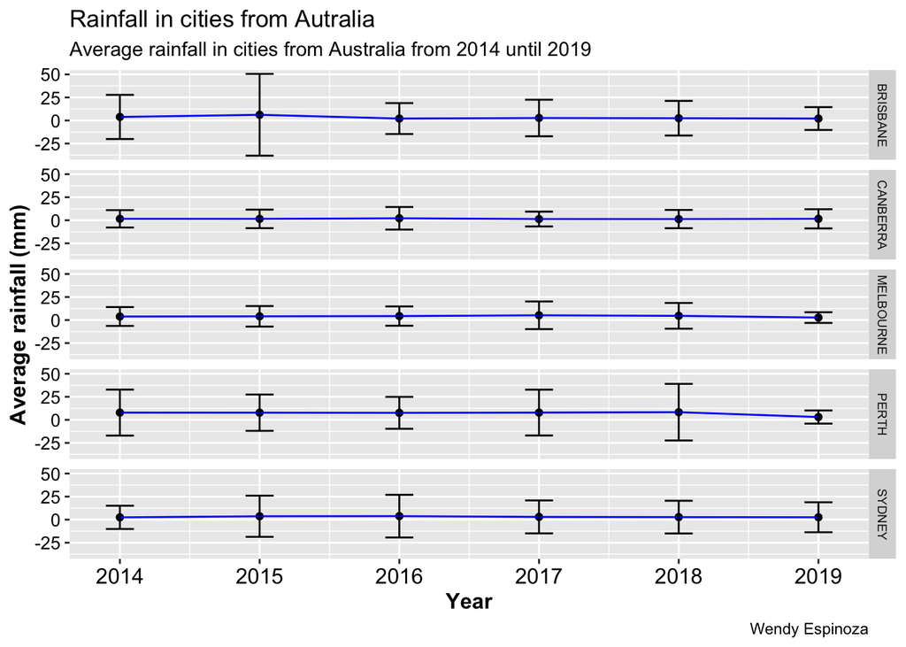

```r
rain_df %>%
  ggplot(aes(
        x = year_dup,
        y = Mean)) +
  geom_point() +geom_line(colour = "blue") +
  facet_grid(city_name ~.) +
  geom_errorbar(aes(ymin= lower_bound, ymax = upper_bound), width= 0.2) +
  labs(title = "Rainfall in cities from Autralia",subtitle = "Average rainfall in cities from Australia from 2014 until 2019", x= "Year", y="Average rainfall (mm)", caption = "Wendy Espinoza") + theme(axis.title.y = element_text(size = 12, face = "bold"),axis.title.x = element_text(size = 12, face = "bold"), legend.title = element_text(size = 12, face = "bold"),
        legend.text = element_text(size = 12, face = "bold", colour = "black"),
        axis.text.y = element_text(colour = "black", size = 10),axis.text.x = element_text(colour = "black", size = 12), strip.text.y = element_text(size = 7))
```

```r
options(width = 120)
```